# Handling and visualizing spatiotemporal data

Guillaume Blanchet & Steve Vissault

November 20th, 2019

# Visualizing spatio-temporal data

## install & load packages

```r
library(robis)
library(sf)
library(dplyr)
library(ggplot2)
library(raster)
library(sf)
library(spacetime)
library(sp)
library(mapview)

# if needed
# install.packages(c("robis","sf","dplyr","ggplot2","raster","sf","spacetime","sp"))
# install_github("andrewzm/STRbook")
```

## Gathering occurrences from OBIS

Explore [OBIS database](https://obis.org/) and get species occurrences for Halibut (*Hippoglossus hippoglossus*).

```r
halibut <- robis::occurrence(scientificname = "Hippoglossus hippoglossus",
               geometry="POLYGON((-64.84626027288095 48.91641792598304,-64.01129933538095 50.49356505646415,-68.82331105413095 50.11464395818477,-71.04254933538095 46.80876488134784,-64.84626027288095 48.91641792598304))"
          )
```

```
## Retrieved 228 records of approximately 228 (100%)
```

## Convert `halibut` dataframe to a sf object

```r
sf_halibut <- st_as_sf(halibut,
                    coords = c("decimalLongitude","decimalLatitude"),
                    crs = 4326)
```

The [OBIS database](https://obis.org/) provide a lot of context on the records.

```r
names(sf_halibut)
```

```
##  [1] "rightsHolder"             "country"
##  [3] "date_year"                "institutionID"
##  [5] "scientificNameID"         "year"
##  [7] "scientificName"           "dynamicProperties"
##  [9] "dropped"                  "aphiaID"
## [11] "language"                 "phylumid"
## [13] "familyid"                 "catalogNumber"
## [15] "basisOfRecord"            "terrestrial"
## [17] "superclass"               "modified"
## [19] "maximumDepthInMeters"     "id"
## [21] "day"                      "order"
## [23] "superclassid"             "dataset_id"
## [25] "collectionCode"           "speciesid"
## [27] "date_end"                 "occurrenceID"
## [29] "license"                  "date_start"
```

[output cut: 20 more lines]

We perform a visual check of the occurrences.

```r
mapview(sf_halibut)
```

[interactive chart not shown]

## Visual representation per year

We can now build a representation of the occurrences per year, but firsts we have to extract the polygon for the area around the estuary.

```r
poly_ca <- raster::getData('GADM', country='CA', level=1)
sf_ca <- st_as_sf(poly_ca)
sf_estuary <- st_crop(sf_ca, st_as_sfc(st_bbox(sf_halibut)))
```

```
## although coordinates are longitude/latitude, st_intersection assumes that they are planar
```

Following, we can visualize the data

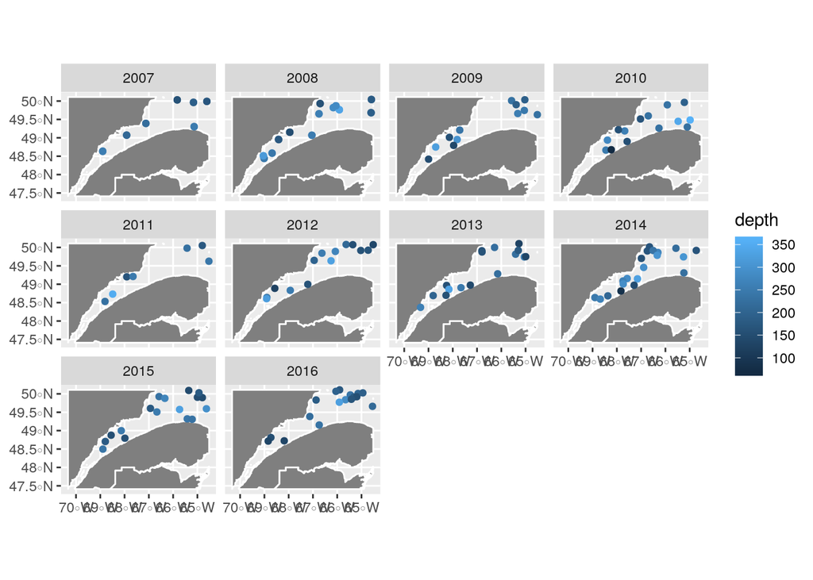

```r
ggplot() +
     geom_sf(data = sf_estuary, fill = "grey50", col = "white") +
     geom_sf(data = filter(sf_halibut, year > 2006), aes(col = depth)) +
     facet_wrap(~year)
```

## Produce count grids

If you have a large dataset with a high density of points, it is a good idea to summarize the informations using a grid of abundance counts.

```r
# get number of years
years <- unique(sf_halibut$year)

# Create a reference grid
ref_grid <- raster(sf_halibut, res=0.05)

# Open empty stack
stack_count <- stack()

for(i in 1:length(years)){
     # Filter for one year (years[i])
     sf_halibut_yr <- filter(sf_halibut, year == years[i])

     # Prepare the geometry
     sp_halibut_yr <- as(st_geometry(sf_halibut_yr), "Spatial")

     # Count points per cell
     rs_count <- rasterize(sp_halibut_yr, ref_grid, fun = 'count')

     # Add the layer to the stack
     stack_count <- addLayer(stack_count,rs_count)
}

names(stack_count) <- years
```

## Practice

1. Collect the occurences of your favorite species on OBIS.
   - `robis::occurrence(scientificname = "Hippoglossus hippoglossus")`
2. Visualize the distribution of this species across several years using `ggplot2`.
3. Produce count grids per year for this species.

# Spatial variability

**Hovmöller plot**

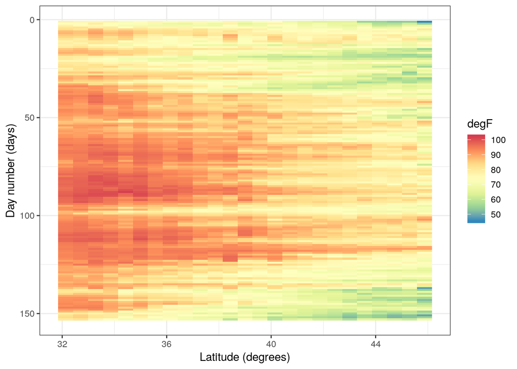

```r
data("NOAA_df_1990", package = "STRbook")

Tmax <- filter(NOAA_df_1990,     # subset the data
              proc == "Tmax" &   # only max temperature
              month %in% 5:9 &   # May to September
              year == 1993)      # year of 1993

lim_lat <- range(Tmax$lat)        # latitude range

lat_axis <- seq(lim_lat[1],       # latitude axis
                lim_lat[2],
                length=25)

Tmax$t <- Tmax$julian - 728049     # create a new time variable
Tmax_grid <- Tmax
dists <- abs(outer(Tmax$lat, lat_axis, "-"))
Tmax_grid$lat <- lat_axis[apply(dists, 1, which.min)]

Tmax_lat_Hov <- group_by(Tmax_grid, lat, t) %>%
                summarise(z = mean(z))

library(STRbook)
Hovmoller_lat <- ggplot(Tmax_lat_Hov) +            # take data
        geom_tile(aes(x = lat, y = t, fill = z)) + # plot
        fill_scale(name = "degF") +     # add color scale
        scale_y_reverse() +             # rev y scale
        ylab("Day number (days)") +     # add y label
        xlab("Latitude (degrees)") +    # add x label
        theme_bw()                      # change theme

Hovmoller_lat
```

# Temporal variability

**Trends plots by stations**

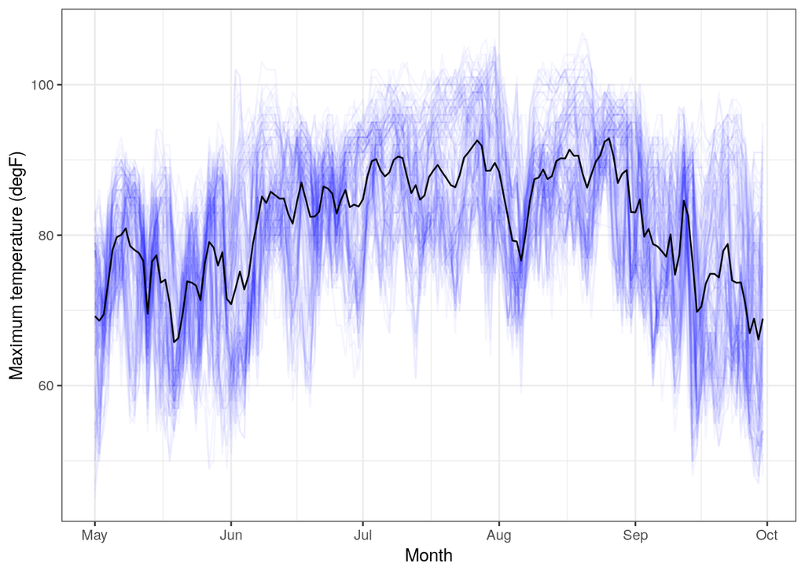

```r
data("NOAA_df_1990", package = "STRbook")

Tmax <- filter(NOAA_df_1990,     # subset the data
              proc == "Tmax" &   # only max temperature
              month %in% 5:9 &   # May to September
              year == 1993)      # year of 1993

Tmax_av <- group_by(Tmax, date) %>%
           summarise(meanTmax = mean(z))

gTmaxav <-
    ggplot() +
    geom_line(data = Tmax,aes(x = date, y = z, group = id),
              colour = "blue", alpha = 0.04) +
    geom_line(data = Tmax_av, aes(x = date, y = meanTmax)) +
    xlab("Month") + ylab("Maximum temperature (degF)") +
    theme_bw()

gTmaxav
```

# Transform your data into `spacetime` classes

To perform spatio-temporal variograms with `gstat`, we need to convert our data into one of the following different `spacetime` classes of object. To build these objects, the best way is to use the `stConstruct` function in the `spacetime` package.

## Get access to the data

[Download PM10 air quality data](https://github.com/SteveViss/PR-GSFE01/raw/master/sp_time_vario/assets/data/air.rds)

## `spacetime` classes

- full grid (STF), a combination of any sp object and any xts object to represent all possible locations on the implied space-time lattice;
- sparse grid (STS), as STF, but contains only the non-missing space-time combinations on a space-time lattice;
- irregular (STI), an irregular space-time data structure, where each point is allocated a spatial coordinate and a time stamp;
- simple trajectories (STT), a sequence of space-time points that form trajectories.

```r
library(spacetime)

raw_air <- readRDS("./assets/data/air.rds")
head(raw_air)
```

```
##   station_id   pm10      dates      lng      lat
## 1    DEBB051  8.688 2001-06-08 14.05746 52.54136
## 2    DEBB051  7.354 2001-09-10 14.05746 52.54136
## 3    DEBB051 15.729 2001-10-10 14.05746 52.54136
## 4    DEBB051 26.312 2001-05-03 14.05746 52.54136
## 5    DEBB051 13.958 2001-10-28 14.05746 52.54136
## 6    DEBB051 39.188 2001-10-16 14.05746 52.54136
```

```r
spaceTime_air <- stConstruct(raw_air, c("lng","lat"),"dates", crs = CRS("+init=epsg:4326"))
class(spaceTime_air)
```

```
## [1] "STIDF"
## attr(,"package")
## [1] "spacetime"
```

```r
# subset
raw_air_062005 <- subset(raw_air, dates > as.Date("2005-06-01") & dates < as.Date("2005-06-30"))

raw_air_062005 <- stConstruct(raw_air_062005, c("lng","lat"),"dates", crs = CRS("+init=epsg:4326"))

# Coerce the STI class to STF
STFDF_air_062005 <- as(raw_air_062005, "STFDF")
summary(STFDF_air_062005)
```

```
## Object of class STFDF
##  with Dimensions (s, t, attr): (46, 28, 2)
## [[Spatial:]]
## Object of class SpatialPoints
## Coordinates:
##          min      max
## lng  6.28107 14.78617
## lat 47.80847 54.92497
## Is projected: FALSE
## proj4string :
## [+init=epsg:4326 +proj=longlat +datum=WGS84 +no_defs +ellps=WGS84
## +towgs84=0,0,0]
## Number of points: 46
## [[Temporal:]]
##      Index              timeIndex
##  Min.   :2005-06-02   Min.   : 1.00
##  1st Qu.:2005-06-08   1st Qu.: 7.75
##  Median :2005-06-15   Median :14.50
##  Mean   :2005-06-15   Mean   :14.50
##  3rd Qu.:2005-06-22   3rd Qu.:21.25
##  Max.   :2005-06-29   Max.   :28.00
## [[Data attributes:]]
##    station_id        pm10
##  DESH001:  28   Min.   : 2.708
##  DENI063:  28   1st Qu.:10.739
##  DEUB038:  28   Median :14.191
##  DEBE056:  28   Mean   :15.100
##  DEBE032:  28   3rd Qu.:18.583
##  (Other):1108   Max.   :53.292
##  NA's   :  40   NA's   :40
```

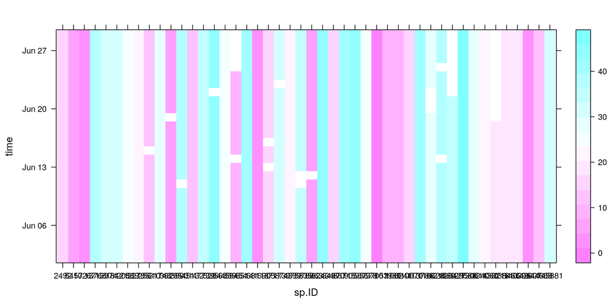

```r
# Hovmöller plot
stplot(STFDF_air_062005, mode = "xt")
```

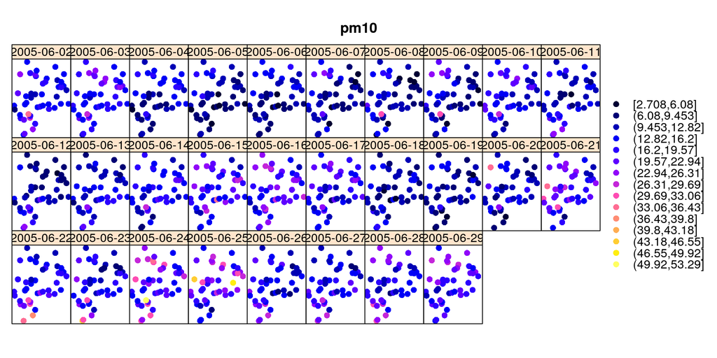

```r
# Temporal-space variability
stplot(STFDF_air_062005[,,"pm10"], mode = "xy")
```